# Categorical predictors

STA 235 Lecture 4

Emre Yucel

University of Texas at Austin

2026-09-24

# Categorical predictors with 2 categories

## Evaluations Dataset

Evaluations of 463 instructors at UT Austin, 2000-2002, for each instructor:

- `eval`: average student evaluation score of instructor
- `beauty`: average beauty rating of instructor from six-student panel
- `gender`: male or female
- `credits`: single or multi-credit course
- `age`: age of instructor
- (and others)

## What’s the impact of gender on student evaluations?

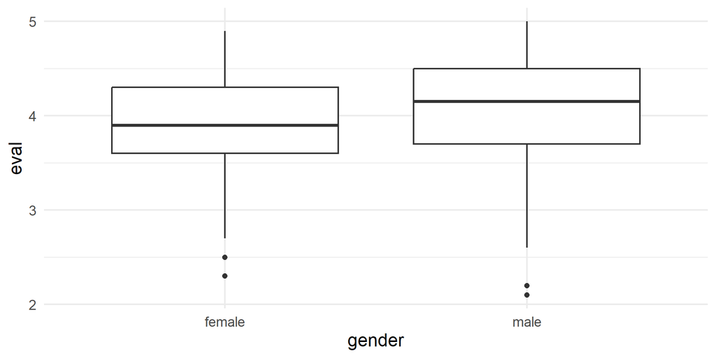

## Incorporating gender into a regression model

- Gender is a categorical variable (male or female in this data set) so we can’t use it as-is as a predictor
- What we’ll do is recode gender into the quantitative “dummy” variable 1 = male, 0 = female
- The ordering is arbitrary. R will choose the alphabetically first category as the 0, or baseline level
- You will be able to tell which coefficient belongs to which level, i.e. `gendermale` means male=1, making female=0

```r
model0 <- lm(eval ~ gender, data=profs)
summary(model0)
```

```
Call:
lm(formula = eval ~ gender, data = profs)

Residuals:
     Min       1Q   Median       3Q      Max
-1.96903 -0.36903  0.03097  0.43097  0.99897

Coefficients:
            Estimate Std. Error t value Pr(>|t|)
(Intercept)  3.90103    0.03933   99.19  < 2e-16 ***
gendermale   0.16800    0.05169    3.25  0.00124 **
---
Signif. codes:  0 '***' 0.001 '**' 0.01 '*' 0.05 '.' 0.1 ' ' 1

Residual standard error: 0.5492 on 461 degrees of freedom
Multiple R-squared:  0.0224,    Adjusted R-squared:  0.02028
F-statistic: 10.56 on 1 and 461 DF,  p-value: 0.001239
```

Compare the fitted model to the means of the two groups:

$$\widehat{\text{eval}} = 3.901 + 0.168\times \text{male}$$

```r
profs %>%
  group_by(gender) %>%
  summarize(mean(eval))
```

```
# A tibble: 2 × 2
  gender `mean(eval)`
  <chr>         <dbl>
1 female         3.90
2 male           4.07
```

What’s going on here?

## Plotting the Regression

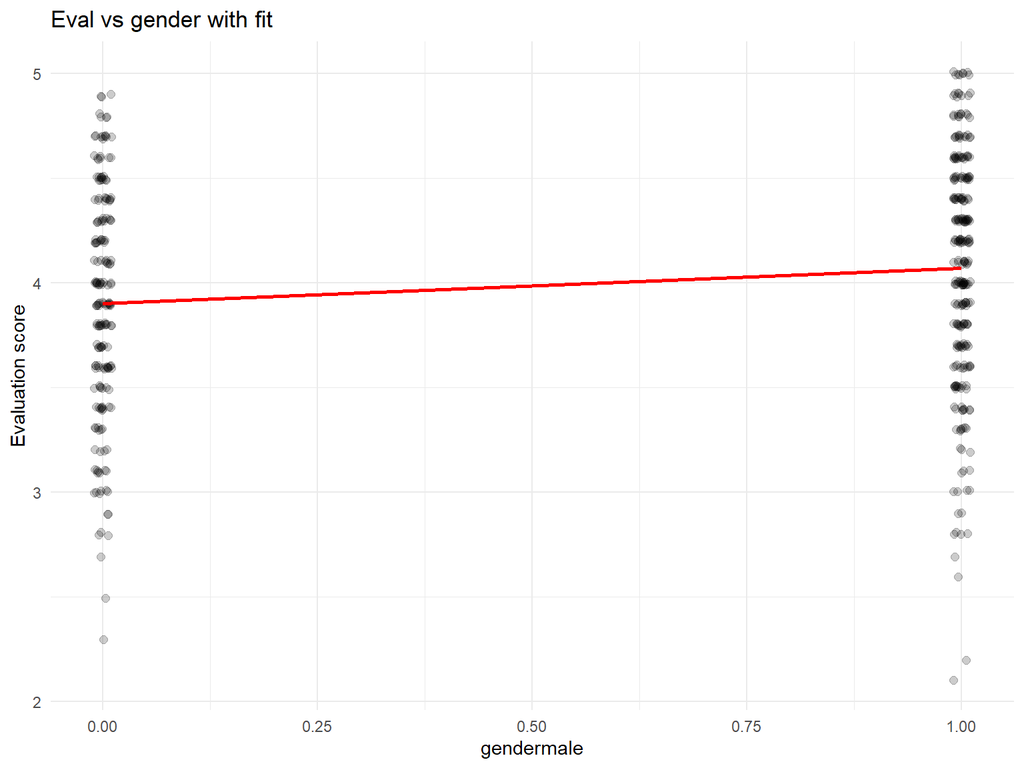

## Selecting a different reference category

You can also pick a reference category using `relevel`:

```r
# Create a new data set where the gender variable has the "male"
# category as the reference category
profs.releveled = profs %>%
  mutate(gender=relevel(factor(gender), "male"))

# Fit the model with this new data set
lm(eval ~ gender, data=profs.releveled)
```

```
Call:
lm(formula = eval ~ gender, data = profs.releveled)

Coefficients:
 (Intercept)  genderfemale
       4.069        -0.168
```

## Plotting the Releveled Regression

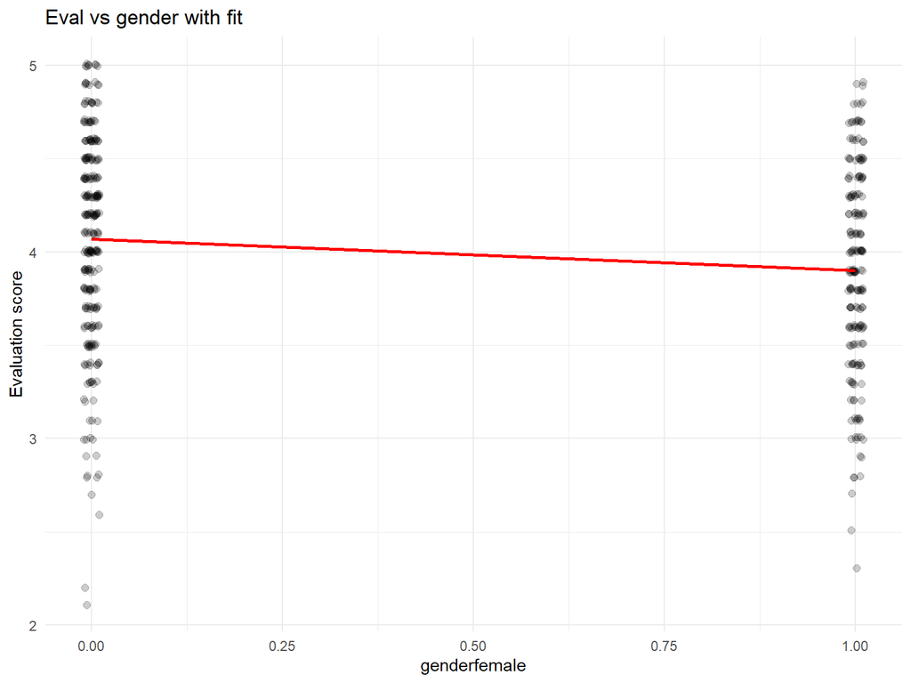

## Incorporating gender into a multiple regression model

- We can easily include categorical variables in *multiple* regression models too
- We still need to think carefully about their interpretation, just like other multiple regression coefficients.

```r
model1 <- lm(eval ~ beauty + gender, data=profs)
summary(model1)
```

```
Call:
lm(formula = eval ~ beauty + gender, data = profs)

Residuals:
     Min       1Q   Median       3Q      Max
-1.87196 -0.36913  0.03493  0.39919  1.03237

Coefficients:
            Estimate Std. Error t value Pr(>|t|)
(Intercept)  3.88377    0.03866  100.47  < 2e-16 ***
beauty       0.14859    0.03195    4.65 4.34e-06 ***
gendermale   0.19781    0.05098    3.88  0.00012 ***
---
Signif. codes:  0 '***' 0.001 '**' 0.01 '*' 0.05 '.' 0.1 ' ' 1

Residual standard error: 0.5373 on 460 degrees of freedom
Multiple R-squared:  0.0663,    Adjusted R-squared:  0.06224
F-statistic: 16.33 on 2 and 460 DF,  p-value: 1.407e-07
```

## Gender Specific Equations

$$\widehat{\text{eval}} = \underbrace{[3.884 + 0.198 \times \text{male}]}_{\text{gender specific intercept}} + 0.149 \times \text{beauty}$$

For females we have
$$\widehat{\text{eval}} = [3.884 + 0.198 \times 0] + 0.149 \times \text{beauty}$$

For males we have
$$\widehat{\text{eval}} = [3.884 + 0.198 \times 1] + 0.149 \times \text{beauty}$$

## Building a multiple regression model using gender

A multiple regression predicting evaluation score from beauty and gender effectively fits two **parallel** regression lines:

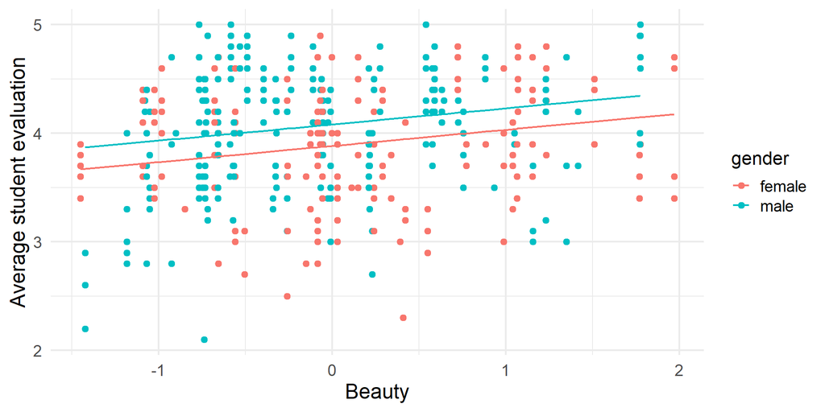

# Categorical predictors with 3+ categories

## Is there a generation gap?

- The variable `generation` is either `silent` (born before 1945), `boomer` (born 1945-1964), or `genx` (born after 1965)
- We already know that there is a difference between male and female professors, and that beauty matters too.
- How would I build a model to determine whether generation matters **above and beyond** `gender` and `beauty`? (i.e., do professors of the same gender and beauty get different evaluations depending on their generation?)

## Why not just convert to numerical variables?

How would things go wrong if we just recoded the generation variable as numeric (e.g., 0 = silent, 1 = boomer, 2 = gen X) and included that in the model?

## Dummy Coding

Let’s arbitrarily pick boomers as a reference category:

| Category | `genx` | `silent` |
| --- | --- | --- |
| Boomers | 0 | 0 |
| Gen Xers | 1 | 0 |
| Silent Gens | 0 | 1 |

R will do this automatically when you add a categorical variable with 3+ categories to a regression (it will arbitrarily pick a reference category)!

```r
model2 <- lm(eval ~ beauty + gender + generation, data=profs)
summary(model2)
```

```
Call:
lm(formula = eval ~ beauty + gender + generation, data = profs)

Residuals:
     Min       1Q   Median       3Q      Max
-1.91613 -0.36042  0.03609  0.42282  1.04398

Coefficients:
                 Estimate Std. Error t value Pr(>|t|)
(Intercept)       3.89727    0.04403  88.521  < 2e-16 ***
beauty            0.14021    0.03304   4.243 2.67e-05 ***
gendermale        0.22230    0.05345   4.159 3.82e-05 ***
generationgenx   -0.02831    0.06149  -0.460   0.6454
generationsilent -0.16292    0.07992  -2.039   0.0421 *
---
Signif. codes:  0 '***' 0.001 '**' 0.01 '*' 0.05 '.' 0.1 ' ' 1

Residual standard error: 0.536 on 458 degrees of freedom
Multiple R-squared:  0.07477,   Adjusted R-squared:  0.06669
F-statistic: 9.253 on 4 and 458 DF,  p-value: 3.386e-07
```

```
                 Estimate Std. Error t value Pr(>|t|)
(Intercept)       3.89727    0.04403  88.521  < 2e-16 ***
beauty            0.14021    0.03304   4.243 2.67e-05 ***
gendermale        0.22230    0.05345   4.159 3.82e-05 ***
generationgenx   -0.02831    0.06149  -0.460   0.6454
generationsilent -0.16292    0.07992  -2.039   0.0421 *
```

All else equal (i.e., among professors of the same gender and beauty):

- Gen X professors are predicted to get scores that are 0.03 points below those of boomers
- Silent gen professors are predicted to get scores that are 0.16 points below those of boomers
- Only the boomer/silent generation difference is statistically significant; gen X professors are not significantly different than boomers
- In other words: **age only seems to matter if you are really old**

## Age & gender specific regression lines

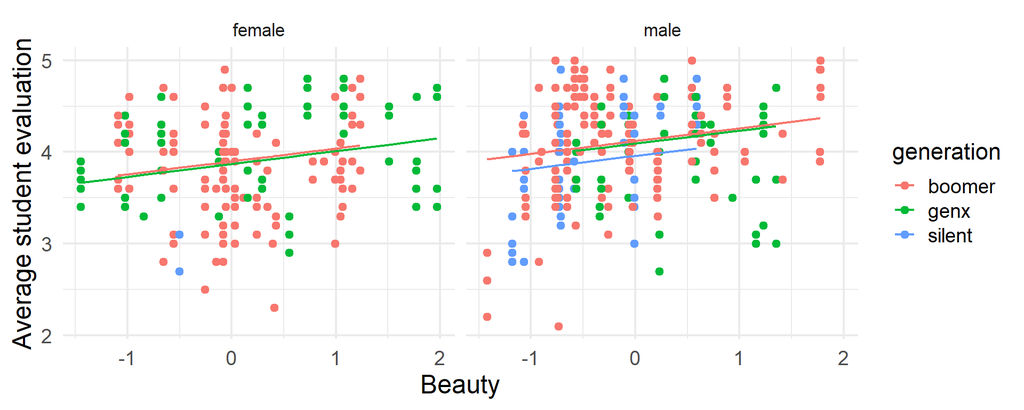

From each combination of age and gender, we have 6 different regression lines

## Confidence intervals

```r
confint(model2)
```

```
                       2.5 %       97.5 %
(Intercept)       3.81075083  3.983789776
beauty            0.07527196  0.205141913
gendermale        0.11725643  0.327335872
generationgenx   -0.14913816  0.092517802
generationsilent -0.31997630 -0.005870264
```

Among professors of the same gender and generation:

- We are 95% confident that an additional beauty point raises evaluation score between 0.075 and 0.205 points
- We have evidence of a statistically significant relationship between beauty and evaluation after adjusting for gender and generation

## Confidence intervals

```r
confint(model2)
```

```
                       2.5 %       97.5 %
(Intercept)       3.81075083  3.983789776
beauty            0.07527196  0.205141913
gendermale        0.11725643  0.327335872
generationgenx   -0.14913816  0.092517802
generationsilent -0.31997630 -0.005870264
```

Among professors of the same gender and beauty:

- The difference between genx and boomer could be anywhere between -0.149 or 0.093 with 95% confidence; we can’t really conclude a relationship
- The difference between silent and boomer could be anywhere between -0.32 or -0.006 with 95% confidence; even though this is statistically significant, it could be a rather weak effect

## Predictions

While we could plug in values to our regression equation for prediction, it gets unwieldy rather quickly

```r
avg_older_male <- data.frame(beauty=0, gender='male', generation='silent')
predict(model2, newdata=avg_older_male, interval='prediction')
```

```
       fit      lwr      upr
1 3.956643 2.893971 5.019315
```

Using R, we have the benefit of being able to get a prediction interval as well

- There’s a 95% chance that an average looking, male, silent generation professor will have an evaluation score in this range
- 95% of average looking, male, silent generation professors will receive evaluations between 2.89 and 5.02